# DS07 - Linear Regression

```r
# add 2002 salary of each player
players <- Salaries %>%
  filter(yearID == 2002) %>%
  select(playerID, salary) %>%
  right_join(players, by="playerID")

# add defensive position
position_names <- c("G_p","G_c","G_1b","G_2b","G_3b","G_ss","G_lf","G_cf","G_rf")
tmp_tab <- Appearances %>%
  filter(yearID == 2002) %>%
  group_by(playerID) %>%
  summarize_at(position_names, sum) %>%
  ungroup()
pos <- tmp_tab %>%
  select(position_names) %>%
  apply(., 1, which.max)
players <- data_frame(playerID = tmp_tab$playerID, POS = position_names[pos]) %>%
  mutate(POS = str_to_upper(str_remove(POS, "G_"))) %>%
  filter(POS != "P") %>%
  right_join(players, by="playerID") %>%
  filter(!is.na(POS)  & !is.na(salary))
# add players' first and last names
players <- Master %>%
  select(playerID, nameFirst, nameLast, debut) %>%
  mutate(debut = as.Date(debut)) %>%
  right_join(players, by="playerID")

# top 10 players
players %>% select(nameFirst, nameLast, POS, salary, R_hat) %>%
  arrange(desc(R_hat)) %>%
  top_n(10)
```

```
##    nameFirst    nameLast POS   salary R_hat
## 1      Barry       Bonds  LF 15000000  9.05
## 2       Todd      Helton  1B  5000000  8.23
## 3      Manny     Ramirez  LF 15462727  8.20
## 4      Sammy        Sosa  RF 15000000  8.19
## 5      Larry      Walker  RF 12666667  8.15
## 6      Jason      Giambi  1B 10428571  7.99
## 7    Chipper       Jones  LF 11333333  7.64
## 8      Brian       Giles  LF  8063003  7.57
## 9     Albert      Pujols  LF   600000  7.54
## 10     Nomar Garciaparra  SS  9000000  7.51
```

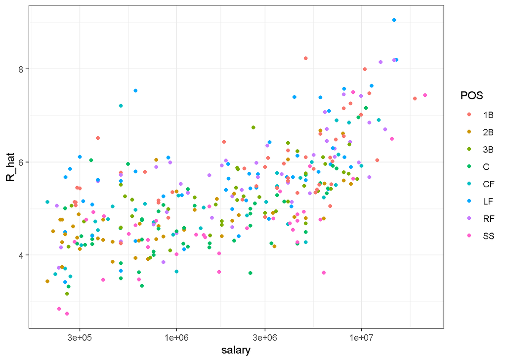

```r
# players with a higher metric have higher salaries
players %>% ggplot(aes(salary, R_hat, color = POS)) +
  geom_point() +
  scale_x_log10()
```

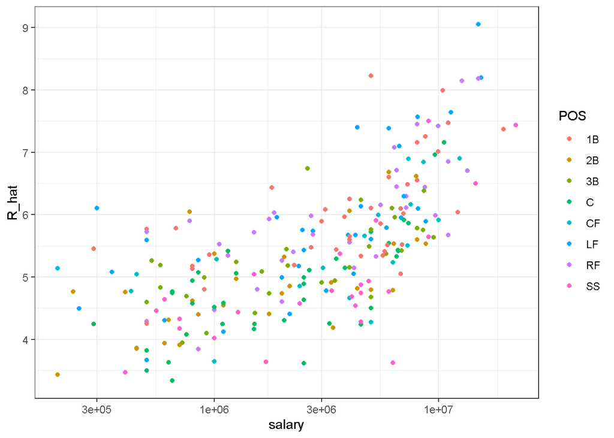

```r
# remake plot without players that debuted after 1998
library(lubridate)
players %>% filter(year(debut) < 1998) %>%
 ggplot(aes(salary, R_hat, color = POS)) +
  geom_point() +
  scale_x_log10()
```

### 2.5.2 Building a Better Offensive Metric for Baseball: Linear Programming

A way to actually pick the players for the team can be done using what computer scientists call **linear programming**. Although we don’t go into this topic in detail in this course, we include the code anyway:

```r
library(reshape2)
library(lpSolve)

players <- players %>% filter(debut <= "1997-01-01" & debut > "1988-01-01")
constraint_matrix <- acast(players, POS ~ playerID, fun.aggregate = length)
npos <- nrow(constraint_matrix)
constraint_matrix <- rbind(constraint_matrix, salary = players$salary)
constraint_dir <- c(rep("==", npos), "<=")
constraint_limit <- c(rep(1, npos), 50*10^6)
lp_solution <- lp("max", players$R_hat,
                  constraint_matrix, constraint_dir, constraint_limit,
                  all.int = TRUE)
```

```r
our_team <- players %>%
  filter(lp_solution$solution == 1) %>%
  arrange(desc(R_hat))
our_team %>% select(nameFirst, nameLast, POS, salary, R_hat)
```

```
##   nameFirst    nameLast POS   salary R_hat
## 1     Larry      Walker  RF 12666667  8.15
## 2     Nomar Garciaparra  SS  9000000  7.51
## 3      Luis    Gonzalez  LF  4333333  7.40
## 4      Mike      Piazza   C 10571429  7.16
## 5       Jim     Edmonds  CF  7333333  6.90
## 6      Phil       Nevin  3B  2600000  6.75
## 7      Greg    Colbrunn  1B  1800000  6.44
## 8     Terry    Shumpert  2B   775000  6.04
```

[output not shown]

```r
my_scale <- function(x) (x - median(x))/mad(x)
players %>% mutate(BB = my_scale(BB),
                   singles = my_scale(singles),
                   doubles = my_scale(doubles),
                   triples = my_scale(triples),
                   HR = my_scale(HR),
                   AVG = my_scale(AVG),
                   R_hat = my_scale(R_hat)) %>%
    filter(playerID %in% our_team$playerID) %>%
    select(nameFirst, nameLast, BB, singles, doubles, triples, HR, AVG, R_hat) %>%
    arrange(desc(R_hat))
```

```
##   nameFirst    nameLast      BB singles doubles triples     HR   AVG R_hat
## 1     Larry      Walker  1.0605  0.6554   0.922   1.562  1.566 2.835 2.904
## 2     Nomar Garciaparra  0.0274  1.6371   3.118   0.336  0.625 3.197 2.244
## 3      Luis    Gonzalez  0.7046  0.0000   1.413   0.537  1.355 1.829 2.133
## 4      Mike      Piazza  0.3129 -0.0547  -0.242  -1.274  2.035 1.252 1.891
## 5       Jim     Edmonds  1.8074 -1.1409   0.674  -0.674  1.264 0.579 1.621
## 6      Phil       Nevin  0.4909 -0.6479   0.764  -1.098  1.548 0.728 1.463
## 7      Greg    Colbrunn  0.2703  0.6546   0.784   0.585  0.475 1.375 1.148
## 8     Terry    Shumpert -0.1576  0.1221   1.326   3.908 -0.123 0.859 0.744
```

[output not shown]

### 2.5.3 On Base Plus Slugging (OPS)

**Key points**

The on-base-percentage plus slugging percentage (OPS) metric is:

$$\frac{BB}{PA}+\left (\frac{Singles+2Doubles+3Triples+4HR}{AB}\right )$$

### 2.5.4 Regression Fallacy

**Textbook link**  
The textbook section on the [regression fallacy can be found here.](https://rafalab.github.io/dsbook/linear-models.html#the-regression-fallacy)

**Key points**

- Regression can bring about errors in reasoning, especially when interpreting individual observations.
- The example showed in the video demonstrates that the **“sophomore slump”** observed in the data is caused by regressing to the mean.

**Code**  
The code to create a table with player ID, their names, and their most played position:

```r
library(Lahman)
playerInfo <- Fielding %>%
    group_by(playerID) %>%
    arrange(desc(G)) %>%
    slice(1) %>%
    ungroup %>%
    left_join(Master, by="playerID") %>%
    select(playerID, nameFirst, nameLast, POS)
```

The code to create a table with only the ROY award winners and add their batting statistics:

```r
ROY <- AwardsPlayers %>%
    filter(awardID == "Rookie of the Year") %>%
    left_join(playerInfo, by="playerID") %>%
    rename(rookie_year = yearID) %>%
    right_join(Batting, by="playerID") %>%
    mutate(AVG = H/AB) %>%
    filter(POS != "P")
```

The code to keep only the rookie and sophomore seasons and remove players who did not play sophomore seasons:

```r
ROY <- ROY %>%
    filter(yearID == rookie_year | yearID == rookie_year+1) %>%
    group_by(playerID) %>%
    mutate(rookie = ifelse(yearID == min(yearID), "rookie", "sophomore")) %>%
    filter(n() == 2) %>%
    ungroup %>%
    select(playerID, rookie_year, rookie, nameFirst, nameLast, AVG)
```

The code to use the `spread` function to have one column for the rookie and sophomore years batting averages:

```r
ROY <- ROY %>% spread(rookie, AVG) %>% arrange(desc(rookie))

ROY
```

```
## # A tibble: 102 x 6
##    playerID  rookie_year nameFirst nameLast rookie sophomore
##    <chr>           <int> <chr>     <chr>     <dbl>     <dbl>
##  1 mccovwi01        1959 Willie    McCovey   0.354     0.238
##  2 suzukic01        2001 Ichiro    Suzuki    0.350     0.321
##  3 bumbral01        1973 Al        Bumbry    0.337     0.233
##  4 lynnfr01         1975 Fred      Lynn      0.331     0.314
##  5 pujolal01        2001 Albert    Pujols    0.329     0.314
##  6 troutmi01        2012 Mike      Trout     0.326     0.323
##  7 braunry02        2007 Ryan      Braun     0.324     0.285
##  8 olivato01        1964 Tony      Oliva     0.323     0.321
##  9 hargrmi01        1974 Mike      Hargrove  0.323     0.303
## 10 darkal01         1948 Al        Dark      0.322     0.276
## # … with 92 more rows
```

The code to calculate the proportion of players who have a lower batting average their sophomore year:

```r
mean(ROY$sophomore - ROY$rookie <= 0)
```

```
## [1] 0.686
```

[output not shown]

The code to do the similar analysis on all players that played the 2013 and 2014 seasons and batted more than 130 times (minimum to win Rookie of the Year):

```r
two_years <- Batting %>%
    filter(yearID %in% 2013:2014) %>%
    group_by(playerID, yearID) %>%
    filter(sum(AB) >= 130) %>%
    summarize(AVG = sum(H)/sum(AB)) %>%
    ungroup %>%
    spread(yearID, AVG) %>%
    filter(!is.na(`2013`) & !is.na(`2014`)) %>%
    left_join(playerInfo, by="playerID") %>%
    filter(POS!="P") %>%
    select(-POS) %>%
    arrange(desc(`2013`)) %>%
    select(nameFirst, nameLast, `2013`, `2014`)

two_years
```

```
## # A tibble: 312 x 4
##    nameFirst nameLast `2013` `2014`
##    <chr>     <chr>     <dbl>  <dbl>
##  1 Miguel    Cabrera   0.348  0.313
##  2 Hanley    Ramirez   0.345  0.283
##  3 Michael   Cuddyer   0.331  0.332
##  4 Scooter   Gennett   0.324  0.289
##  5 Joe       Mauer     0.324  0.277
##  6 Mike      Trout     0.323  0.287
##  7 Chris     Johnson   0.321  0.263
##  8 Freddie   Freeman   0.319  0.288
##  9 Yasiel    Puig      0.319  0.296
## 10 Yadier    Molina    0.319  0.282
## # … with 302 more rows
```

The code to see what happens to the worst performers of 2013:

```r
arrange(two_years, `2013`)
```

```
## # A tibble: 312 x 4
##    nameFirst nameLast  `2013` `2014`
##    <chr>     <chr>      <dbl>  <dbl>
##  1 Danny     Espinosa   0.158  0.219
##  2 Dan       Uggla      0.179  0.149
##  3 Jeff      Mathis     0.181  0.2
##  4 Melvin    Upton      0.184  0.208
##  5 Adam      Rosales    0.190  0.262
##  6 Aaron     Hicks      0.192  0.215
##  7 Chris     Colabello  0.194  0.229
##  8 J. P.     Arencibia  0.194  0.177
##  9 Tyler     Flowers    0.195  0.241
## 10 Ryan      Hanigan    0.198  0.218
## # … with 302 more rows
```

The code to see the correlation for performance in two separate years:

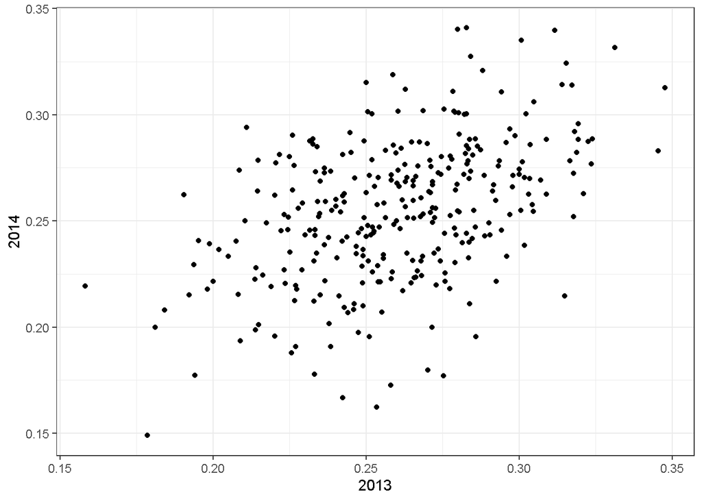

```r
qplot(`2013`, `2014`, data = two_years)
```

```r
summarize(two_years, cor(`2013`,`2014`))
```

```
## # A tibble: 1 x 1
##   `cor(\`2013\`, \`2014\`)`
##                       <dbl>
## 1                     0.460
```

### 2.5.5 Measurement Error Models

**Textbook link**  
The textbook section on [measurement error models can be found here.](https://rafalab.github.io/dsbook/linear-models.html#measurement-error-models)

**Key points**

- Up to now, all our linear regression examples have been applied to two or more random variables. We assume the pairs are bivariate normal and use this to motivate a linear model.
- Another use for linear regression is with **measurement error models**, where it is common to have a non-random covariate (such as time). Randomness is introduced from measurement error rather than sampling or natural variability.

**Code**  
The code to use `dslabs` function `rfalling_object` to generate simulations of dropping balls:

```r
library(dslabs)
falling_object <- rfalling_object()
```

The code to draw the trajectory of the ball:

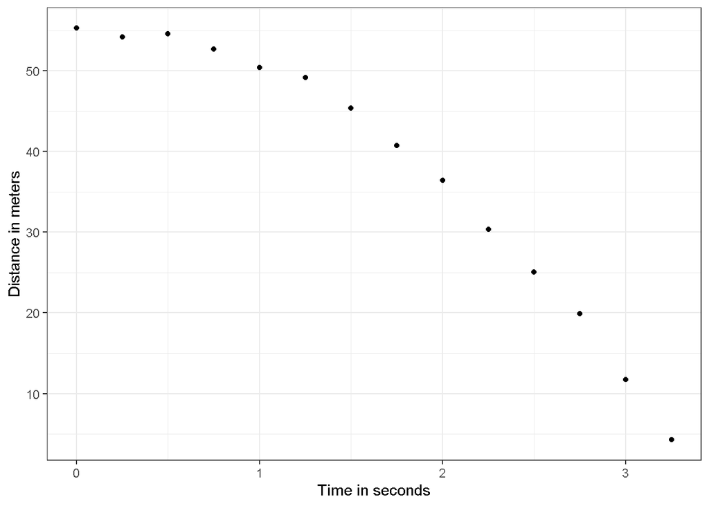

```r
falling_object %>%
    ggplot(aes(time, observed_distance)) +
    geom_point() +
    ylab("Distance in meters") +
    xlab("Time in seconds")
```

The code to use the `lm()` function to estimate the coefficients:

```r
fit <- falling_object %>%
    mutate(time_sq = time^2) %>%
    lm(observed_distance~time+time_sq, data=.)

tidy(fit)
```

```
## # A tibble: 3 x 5
##   term        estimate std.error statistic  p.value
##   <chr>          <dbl>     <dbl>     <dbl>    <dbl>
## 1 (Intercept)   55.0       0.434    127.   9.15e-19
## 2 time           0.888     0.620      1.43 1.80e- 1
## 3 time_sq       -5.08      0.184    -27.7  1.61e-11
```

[output not shown]

The code to check if the estimated parabola fits the data:

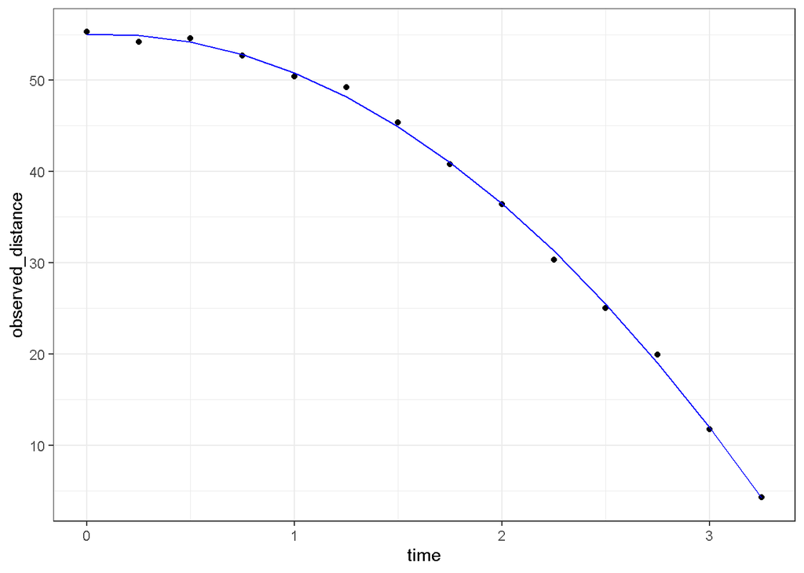

```r
augment(fit) %>%
    ggplot() +
    geom_point(aes(time, observed_distance)) +
    geom_line(aes(time, .fitted), col = "blue")
```

The code to see the summary statistic of the regression:

```r
tidy(fit, conf.int = TRUE)
```

```
## # A tibble: 3 x 7
##   term        estimate std.error statistic  p.value conf.low conf.high
##   <chr>          <dbl>     <dbl>     <dbl>    <dbl>    <dbl>     <dbl>
## 1 (Intercept)   55.0       0.434    127.   9.15e-19   54.1       56.0
## 2 time           0.888     0.620      1.43 1.80e- 1   -0.476      2.25
## 3 time_sq       -5.08      0.184    -27.7  1.61e-11   -5.49      -4.68
```

[output not shown]

### 2.5.6 Assessment: Regression and Baseball, part 1

#### 2.5.6.1 Question 1

What is the final linear model (in the video “Building a Better Offensive Metric for Baseball”) we used to predict runs scored per game?

- `lm(R ~ BB + HR)`
- `lm(HR ~ BB + singles + doubles + triples)`
- **`lm(R ~ BB + singles + doubles + triples + HR)`**
- `lm(R ~ singles + doubles + triples + HR)`

**Explanation**  
`lm(R ~ BB + singles + doubles + triples + HR)` is the only one of the models above that predicts runs scored based on all of the following: BBs, singles, doubles, triples, and HRs.

#### 2.5.6.2 Question 2

We want to estimate runs per game scored by individual players, not just by teams. What summary metric do we calculate to help estimate this?

Look at the code from the video “Building a Metter Offensive Metric for Baseball” for a hint:

```r
pa_per_game <- Batting %>%
  filter(yearID == 2002) %>%
  group_by(teamID) %>%
  summarize(pa_per_game = sum(AB+BB)/max(G)) %>%
  .$pa_per_game %>%
  mean
```

The summary metric used is:

- `pa_per_game`: the mean number of plate appearances per team per game for each team
- `pa_per_game`: the mean number of plate appearances per game for each player
- ``pa_per_game`: **the number of plate appearances per team per game, averaged across all teams**

**Explanation**  
`pa_per_game` is the number of plate appearances per team per game averaged across all teams. We initially calculated the `pa_per_game` grouped by teams but then took the means across all teams to get one summary metric.

#### 2.5.6.3 Question 3

Imagine you have two teams. Team A is comprised of batters who, on average, get two bases on balls, four singles, one double, and one home run. Team B is comprised of batters who, on average, get one base on balls, six singles, two doubles, and one triple.

Which team scores more runs, as predicted by our model?

- Team A
- **Team B**
- Tie
- Impossible to know

**Explanation**  
By using the coefficients from the linear model to predict the number of runs scored by each team, you find that Team B is expected to score more runs on average.

#### 2.5.6.4 Question 4

The on-base-percentage plus slugging percentage (OPS) metric gives the most weight to:

- Singles
- Doubles
- Triples
- **Home Runs**

**Explanation**  
By looking at the equation for OPS, you can tell that the OPS metric weights home runs most heavily.

$$OPS=\frac{BB}{PA}+\frac{Singles+2Doubles+3Triples+4HR}{AB}$$

#### 2.5.6.5 Question 5

What statistical concept properly explains the “sophomore slump”?

- **Regression to the mean**
- Law of averages
- Normal distribution

**Explanation** Regression to the mean is what explains the sophomore slump. The correlation for performance in two separate years is high but not perfect, so high performers will tend to perform slightly worse in the following year (and low performers will tend to perform slightly better in the following year).

#### 2.5.6.6 Question 6

In our model of time vs. observed_distance in the video “Measurement Error Models”, the randomness of our data was due to:

- sampling
- natural variability
- **measurement error**

**Explanation**  
Measurement error models look at applications where randomness is introduced from measurement error instead of sampling or natural variability.

#### 2.5.6.7 Question 7

Which of the following are important assumptions about the measurement errors in the experiment presented in the video “Measurement Error Models”? Select ALL that apply.

- **The measurement error is random**
- **The measurement error is independent**
- **The measurement error has the same distribution for each time $i$**

**Explanation**  
In this model, we asumed that the measurement errors were random, independent from each other, and had the same distribution for each time $i$.

We also assumed that there was no bias, which means that $E[\epsilon]=0$.

#### 2.5.6.8 Question 8

Which of the following scenarios would violate an assumption of our measurement error model?

- The experiment was conducted on the moon.
- **There was one position where it was particularly difficult to see the dropped ball.**
- The experiment was only repeated 10 times, not 100 times. incorreta

**Explanation**  
If there were one position where it was particularly difficult to see the dropped ball, that would violate the assumption of randomness. If the experiment were conducted on the moon, that would simply predict a different gravitational constant. Repeating the experiment 10 instead of 100 times would not matter because we do not need a large sample for our assumptions to be valid in this model.

### 2.5.7 Assessment: Regression and baseball, part 2

Question 9 has two parts. Use the information below to answer both parts.

Use the `Teams` data frame from the **Lahman** package. Fit a multivariate linear regression model to obtain the effects of BB and HR on Runs (`R`) in 1971. Use the `tidy` function in the `broom` package to obtain the results in a data frame.

*Clarification: For questions 9-11, do **not** normalize by number of games. For example, use R rather than R/G.*

#### 2.5.7.1 Question 9a

What is the estimate for the effect of BB on runs?

```r
library(Lahman)
library(broom)
Teams %>%
    filter(yearID == 1971) %>%
    lm(R ~ BB + HR, data = .) %>%
    tidy() %>%
    filter(term == "BB") %>%
    pull(estimate)
```

```
## [1] 0.414
```

What is the estimate for the effect of HR on runs?

```r
Teams %>%
    filter(yearID == 1971) %>%
    lm(R ~ BB + HR, data = .) %>%
    tidy() %>%
    filter(term == "HR") %>%
    pull(estimate)
```

```
## [1] 1.3
```

#### 2.5.7.2 Question 9b

Interpret the p-values for the estimates using a cutoff of 0.05.

Which of the following is the correct interpretation?

- Both BB and HR have a nonzero effect on runs.
- **HR has a significant effect on runs, but the evidence is not strong enough to suggest BB also does.**
- BB has a significant effect on runs, but the evidence is not strong enough to suggest HR also does.
- Neither BB nor HR have a statistically significant effect on runs.

**Explanation**  
The p-value for HR is less than 0.05, but the p-value of BB is greater than 0.05 (0.06), so the evidence is not strong enough to suggest that BB has a significant effect on runs at a p-value cutoff of 0.05.

#### 2.5.7.3 Question 10

Repeat the above exercise to find the effects of BB and HR on runs (`R`) for every year from 1961 to 2018 using `do` and the `broom` package.

Make a scatterplot of the estimate for the effect of BB on runs over time and add a trend line with confidence intervals.

Fill in the blank to complete the statement:

The effect of BB on runs has **increased** over time.

**Explanation**  
The scatterplot with trendline can be made using the following code:

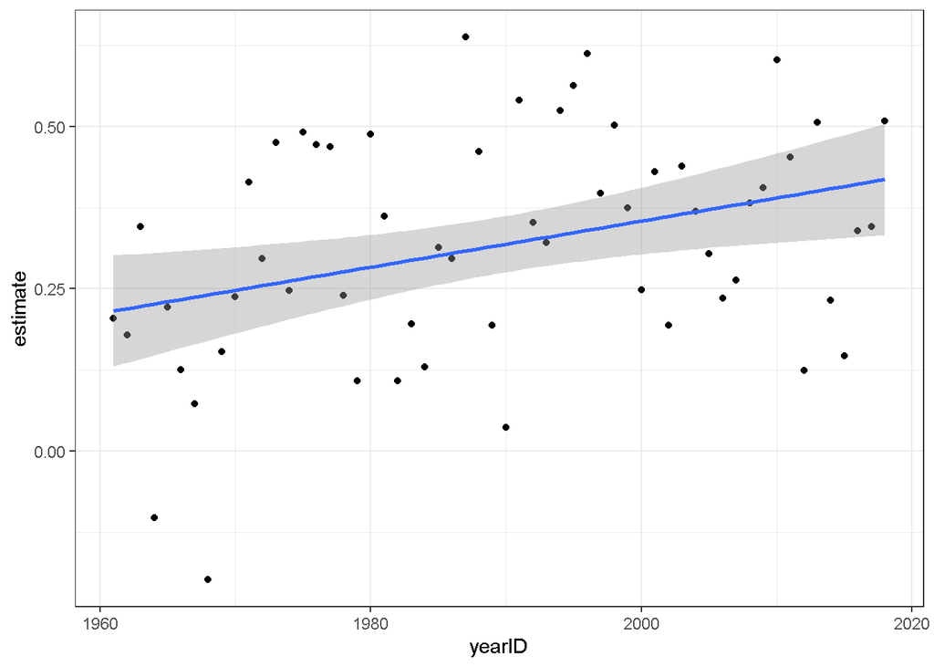

```r
res <- Teams %>%
    filter(yearID %in% 1961:2018) %>%
    group_by(yearID) %>%
    do(tidy(lm(R ~ BB + HR, data = .))) %>%
    ungroup()
res %>%
    filter(term == "BB") %>%
    ggplot(aes(yearID, estimate)) +
    geom_point() +
    geom_smooth(method = "lm")
```

#### 2.5.7.4 Question 11

Fit a linear model on the results from Question 10 to determine the effect of year on the impact of BB.

For each additional year, by what value does the impact of BB on runs change?  
Recall from the instructions at the top of the page that you should not normalize by the number of games (use `R` and `BB` instead of `R/G` and `BB/G`.

```r
res %>%
    filter(term == "BB") %>%
    lm(estimate ~ yearID, data = .) %>%
    tidy() %>%
    filter(term == "yearID") %>%
    pull(estimate)
```

```
## [1] 0.00355
```

What is the p-value for this effect?

```r
res %>%
    filter(term == "BB") %>%
    lm(estimate ~ yearID, data = .) %>%
    tidy() %>%
    filter(term == "yearID") %>%
    pull(p.value)
```

```
## [1] 0.00807
```

# 3 Section 3: Confounding

## 3.1 Confounding Overview

In the **Confounding** section, you will learn what is perhaps the most important lesson of statistics: that correlation is not causation.

After completing this section, you will be able to:

- Identify examples of **spurious correlation** and explain how **data dredging** can lead to spurious correlation.
- Explain how **outliers** can drive correlation and learn to adjust for outliers using **Spearman correlation**.
- Explain how **reversing cause and effect** can lead to associations being confused with causation.
- Understand how **confounders** can lead to the misinterpretation of associations.
- Explain and give examples of **Simpson’s Paradox**.

This section has one part: **Correlation is Not Causation**. There is a comprehension checks at the end of this part, along with an assessment at the end of the section for Verified learners only.

We encourage you to use R to interactively test out your answers and further your own learning. If you get stuck, we encourage you to search the discussion boards for the answer to your issue or ask us for help!

## 3.2 Correlation is Not Causation

### 3.2.1 Correlation is Not Causation: Spurious Correlation

**Textbook link**  
The textbook section on [spurious correlation can be found here.](https://rafalab.github.io/dsbook/association-is-not-causation.html#spurious-correlation)

**Key points**

- Association/correlation is not causation.
- p-hacking is a topic of much discussion because it is a problem in scientific publications. Because publishers tend to reward statistically significant results over negative results, there is an incentive to report significant results.

**Code**

```r
# generate the Monte Carlo simulation
N <- 25
g <- 1000000
sim_data <- tibble(group = rep(1:g, each = N), x = rnorm(N * g), y = rnorm(N * g))

# calculate correlation between X,Y for each group
res <- sim_data %>%
  group_by(group) %>%
  summarize(r = cor(x, y)) %>%
  arrange(desc(r))
res
```

```
## # A tibble: 1,000,000 x 2
##     group     r
##     <int> <dbl>
##  1 840003 0.794
##  2 767028 0.791
##  3 971856 0.776
##  4 212248 0.768
##  5  60200 0.761
##  6  27045 0.756
##  7 114409 0.756
##  8 755537 0.754
##  9 422986 0.753
## 10 789165 0.747
## # … with 999,990 more rows
```

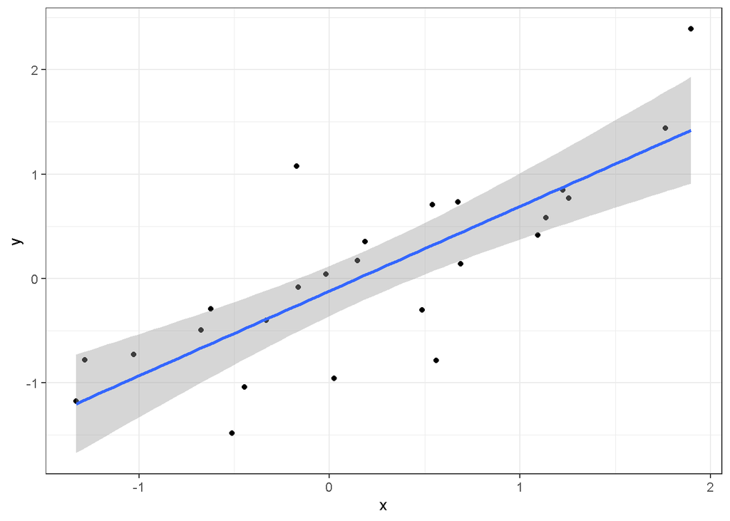

```r
# plot points from the group with maximum correlation
sim_data %>% filter(group == res$group[which.max(res$r)]) %>%
  ggplot(aes(x, y)) +
  geom_point() +
  geom_smooth(method = "lm")
```

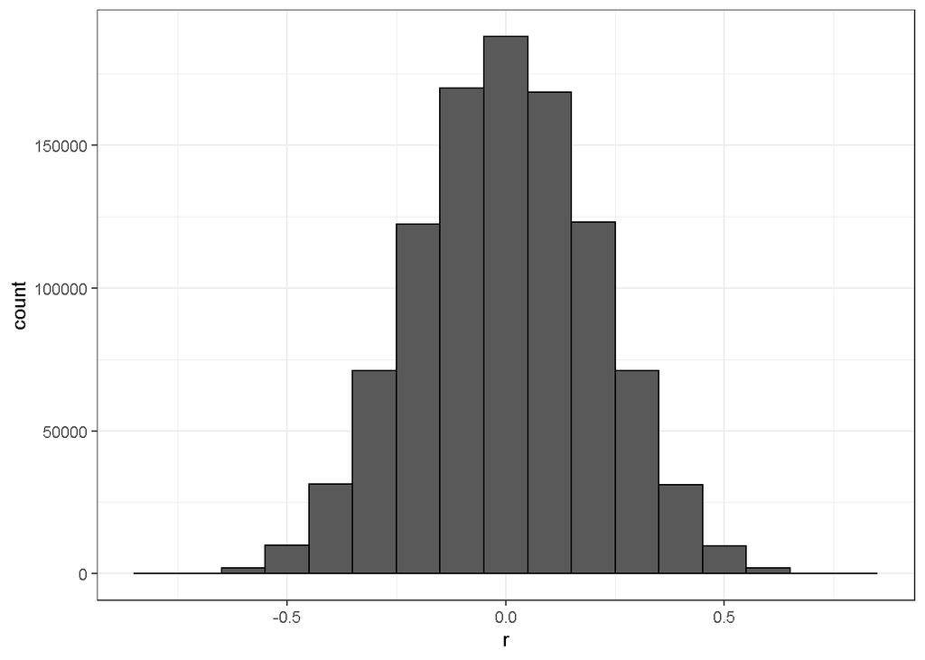

```r
# histogram of correlation in Monte Carlo simulations
res %>% ggplot(aes(x=r)) + geom_histogram(binwidth = 0.1, color = "black")
```

```r
# linear regression on group with maximum correlation
library(broom)
sim_data %>%
  filter(group == res$group[which.max(res$r)]) %>%
  do(tidy(lm(y ~ x, data = .)))
```

```
## # A tibble: 2 x 5
##   term        estimate std.error statistic    p.value
##   <chr>          <dbl>     <dbl>     <dbl>      <dbl>
## 1 (Intercept)   -0.121     0.116     -1.04 0.309
## 2 x              0.812     0.130      6.27 0.00000213
```

### 3.2.2 Correlation is Not Causation: Outliers

**Textbook link**  
The textbook section on [outliers can be found here.](https://rafalab.github.io/dsbook/association-is-not-causation.html#outliers-1)

**Key points**

- Correlations can be caused by **outliers**.
- The **Spearman correlation** is calculated based on the ranks of data.

**Code**

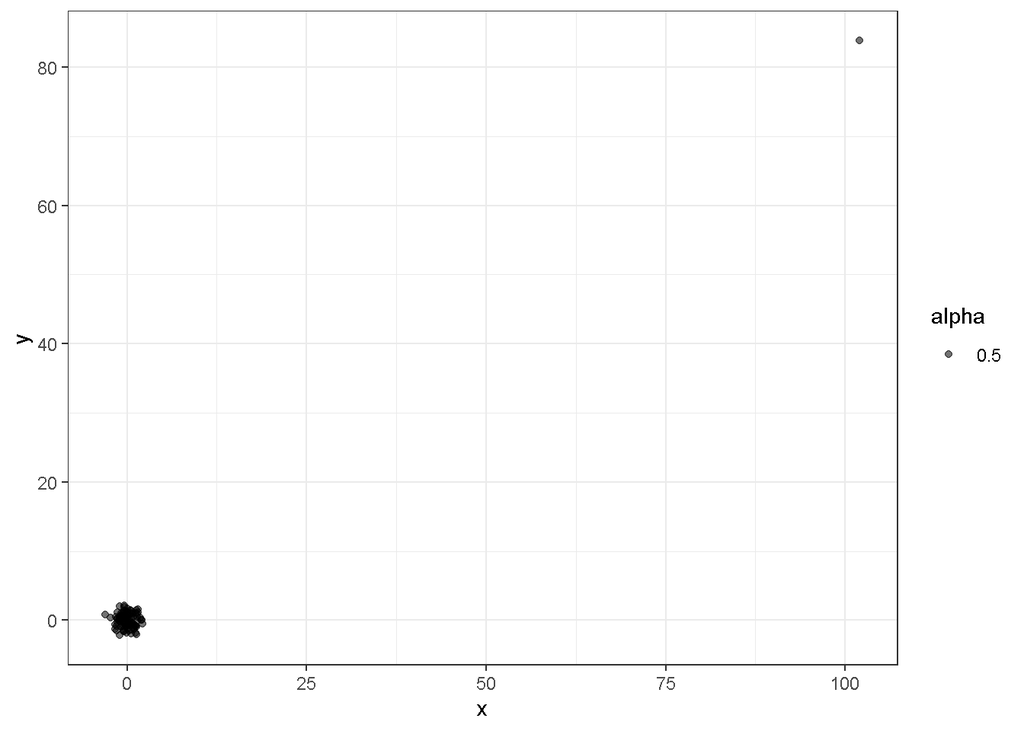

```r
# simulate independent X, Y and standardize all except entry 23
set.seed(1985)
x <- rnorm(100,100,1)
y <- rnorm(100,84,1)
x[-23] <- scale(x[-23])
y[-23] <- scale(y[-23])

# plot shows the outlier
qplot(x, y, alpha = 0.5)
```

```r
# outlier makes it appear there is correlation
cor(x,y)
```

```
## [1] 0.988
```

```r
cor(x[-23], y[-23])
```

```
## [1] -0.0442
```

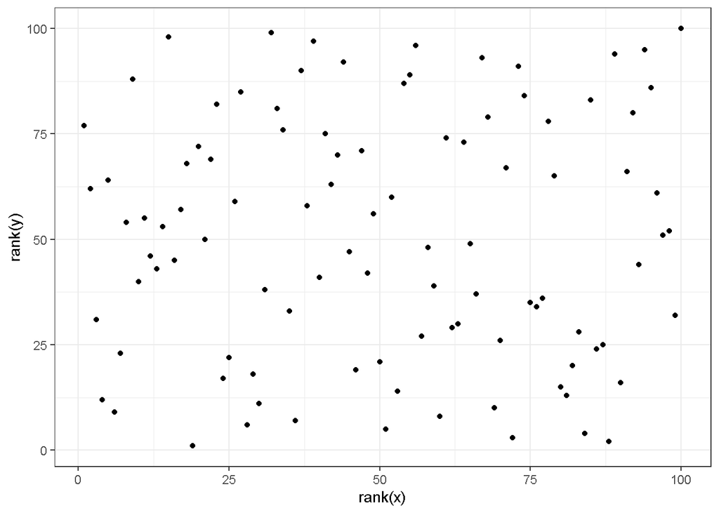

```r
# use rank instead
qplot(rank(x), rank(y))
```

```r
cor(rank(x), rank(y))
```

```
## [1] 0.00251
```

```r
# Spearman correlation with cor function
cor(x, y, method = "spearman")
```

```
## [1] 0.00251
```

### 3.2.3 Correlation is Not Causation: Reversing Cause and Effect

**Textbook link**  
The textbook section on [reversing cause and effect can be found here.](https://rafalab.github.io/dsbook/association-is-not-causation.html#reversing-cause-and-effect)

**Key points**

- Another way association can be confused with causation is when the **cause and effect are reversed.**
- As discussed in the video, in the Galton data, when father and son were reversed in the regression, the model was technically correct. The estimates and p-values were obtained correctly as well. What was incorrect was the **interpretation** of the model.

**Code**

```r
# cause and effect reversal using son heights to predict father heights
library(HistData)
data("GaltonFamilies")
GaltonFamilies %>%
  filter(childNum == 1 & gender == "male") %>%
  select(father, childHeight) %>%
  rename(son = childHeight) %>%
  do(tidy(lm(father ~ son, data = .)))
```

```
## # A tibble: 2 x 5
##   term        estimate std.error statistic  p.value
##   <chr>          <dbl>     <dbl>     <dbl>    <dbl>
## 1 (Intercept)   34.0      4.57        7.44 4.31e-12
## 2 son            0.499    0.0648      7.70 9.47e-13
```

### 3.2.4 Correlation is Not Causation: Confounders

**Textbook link**  
The textbook section on [confounders can be found here.](https://rafalab.github.io/dsbook/association-is-not-causation.html#confounders)

**Key points**

- If X and Y are correlated, we call Z a **confounder** if changes in Z causes changes in both X and Y.

**Code**

```r
# UC-Berkeley admission data
library(dslabs)
data(admissions)
admissions
```

```
##    major gender admitted applicants
## 1      A    men       62        825
## 2      B    men       63        560
## 3      C    men       37        325
## 4      D    men       33        417
## 5      E    men       28        191
## 6      F    men        6        373
## 7      A  women       82        108
## 8      B  women       68         25
## 9      C  women       34        593
## 10     D  women       35        375
## 11     E  women       24        393
## 12     F  women        7        341
```

```r
# percent men and women accepted
admissions %>% group_by(gender) %>%
  summarize(percentage =
              round(sum(admitted*applicants)/sum(applicants),1))
```

```
## # A tibble: 2 x 2
##   gender percentage
##   <chr>       <dbl>
## 1 men          44.5
## 2 women        30.3
```

```r
# test whether gender and admission are independent
admissions %>% group_by(gender) %>%
  summarize(total_admitted = round(sum(admitted / 100 * applicants)),
            not_admitted = sum(applicants) - sum(total_admitted)) %>%
  select(-gender) %>%
  do(tidy(chisq.test(.)))
```

```
## # A tibble: 1 x 4
##   statistic  p.value parameter method
##       <dbl>    <dbl>     <int> <chr>
## 1      91.6 1.06e-21         1 Pearson's Chi-squared test with Yates' continuit…
```

```r
# percent admissions by major
admissions %>% select(major, gender, admitted) %>%
  spread(gender, admitted) %>%
  mutate(women_minus_men = women - men)
```

```
##   major men women women_minus_men
## 1     A  62    82              20
## 2     B  63    68               5
## 3     C  37    34              -3
## 4     D  33    35               2
## 5     E  28    24              -4
## 6     F   6     7               1
```

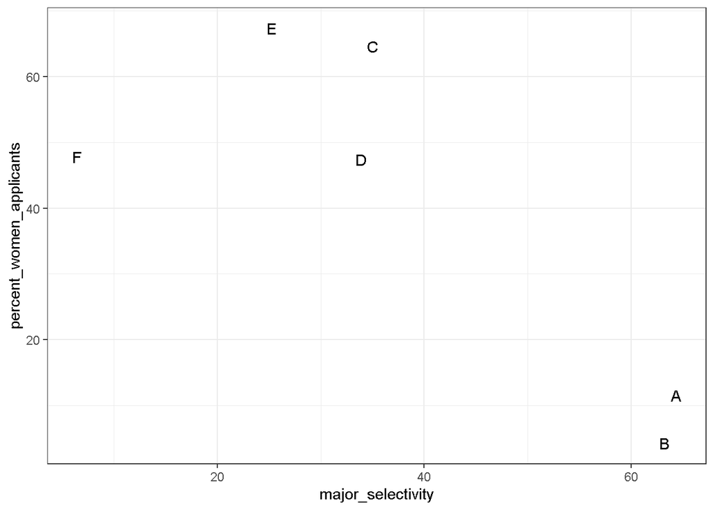

```r
# plot total percent admitted to major versus percent women applicants
admissions %>%
  group_by(major) %>%
  summarize(major_selectivity = sum(admitted * applicants) / sum(applicants),
            percent_women_applicants = sum(applicants * (gender=="women")) /
                                             sum(applicants) * 100) %>%
  ggplot(aes(major_selectivity, percent_women_applicants, label = major)) +
  geom_text()
```

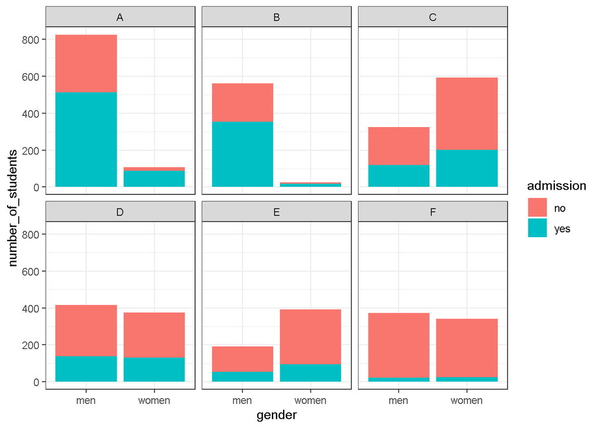

```r
# plot number of applicants admitted and not
admissions %>%
  mutate(yes = round(admitted/100*applicants), no = applicants - yes) %>%
  select(-applicants, -admitted) %>%
  gather(admission, number_of_students, -c("major", "gender")) %>%
  ggplot(aes(gender, number_of_students, fill = admission)) +
  geom_bar(stat = "identity", position = "stack") +
  facet_wrap(. ~ major)
```

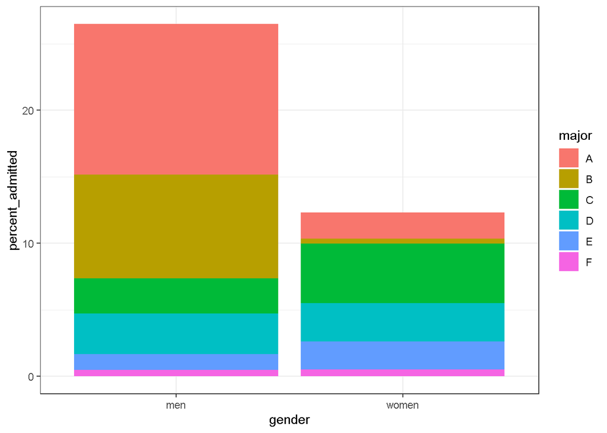

```r
admissions %>%
  mutate(percent_admitted = admitted * applicants/sum(applicants)) %>%
  ggplot(aes(gender, y = percent_admitted, fill = major)) +
  geom_bar(stat = "identity", position = "stack")
```

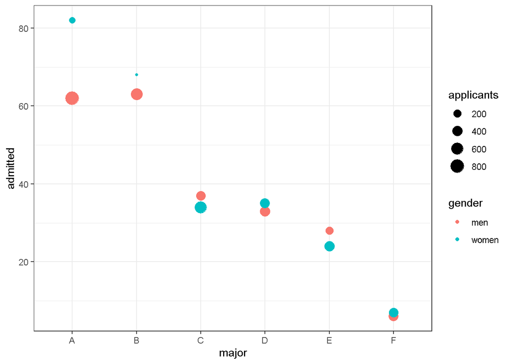

```r
# condition on major and then look at differences
admissions %>% ggplot(aes(major, admitted, col = gender, size = applicants)) + geom_point()
```

```r
# average difference by major
admissions %>%  group_by(gender) %>% summarize(average = mean(admitted))
```

```
## # A tibble: 2 x 2
##   gender average
##   <chr>    <dbl>
## 1 men       38.2
## 2 women     41.7
```

### 3.2.5 Simpson’s Paradox

**Textbook link**  
The textbook section on [Simpson’s paradox can be found here.](https://rafalab.github.io/dsbook/association-is-not-causation.html#simpsons-paradox)

**Key points**

- Simpson’s Paradox happens when we see the sign of the correlation flip when comparing the entire dataset with specific strata.

### 3.2.6 Assessment: Correlation is Not Causation

#### 3.2.6.1 Question 1

In the videos, we ran one million tests of correlation for two random variables, X and Y.

How many of these correlations would you expect to have a significant p-value ($p≤0.05$), just by chance?

- 5,000
- **50,000**
- 100,000
- It’s impossible to know

**Answer**  
In this example, the chance of finding a correlation when none exists is 0.05*1,000,000 chances.

**Explanation**  
The p-value is defined as the probability of finding the observed result when the null hypothesis (no correlation) is true. When we have a p-value of 0.05, this means the chance of finding a correlation when none exists is 5% - e.g., 0.05*1,000,000 chances, which is 50,000.

#### 3.2.6.2 Question 2

Which of the following are examples of p-hacking?  
Select ALL that apply.

- **Looking for associations between an outcome and several exposures and only reporting the one that is significant.**
- **Trying several different models and selecting the one that yields the smallest p-value.**
- **Repeating an experiment multiple times and only reporting the one with the smallest p-value.**
- Using a Monte Carlo simulations in an analysis.

**Explanation**  
Repeating an experiment multiple times and only reporting the one with the smallest p-value, looking for associations between an outcome and several exposures and only reporting the one that is significant, and trying several different models and selecting the one that yields the smallest p-value are all examples of p-hacking.

Monte Carlo simulations do not necessarily lead to multiple testing problems such as p-hacking in and of themselves.

#### 3.2.6.3 Question 3

The Spearman correlation coefficient is robust to outliers because:

- It drops outliers before calculating correlation.
- It is the correlation of standardized values.
- **It calculates correlation between ranks, not values.**

**Explanation**  
Because the Spearman correlation coefficient uses ranks instead of values to calculate correlation, it is more robust to outliers.

#### 3.2.6.4 Question 4

Which of the following may be examples of reversed cause and effect?  
Select ALL that apply.

- **Past smokers who have quit smoking may be more likely to die from lung cancer.**
- Tall fathers are more likely to have tall sons.
- **People with high blood pressure tend to have a healthier diet.**
- **Individuals in a low social status have a higher risk of schizophrenia.**

**Answer**  
Correct - it is possible that a smoker would quit after being diagnosed, but is at a higher risk of dying. It does not mean that quitting smoking increases your risk of dying from lung cancer. Correct. This could be reverse causation. Individuals with high blood pressure may have a healthier diet because they are trying to improve their blood pressure, not because a healthy diet causes high blood pressure. Correct. This could be reverse causation. It is possible that individuals with schizophrenia are more likely to have a lower social status due to the challenges of managing their disease.

**Explanation**  
“Past smokers who have quit smoking may be more likely to die from lung cancer” is an example because it is possible that a smoker would quit after being diagnosed, but is at a higher risk of dying. However, it does not mean that quitting smoking increases your risk of dying from lung cancer.

For the statement “tall fathers are more likely to have tall sons,” we know the order of causation because the fathers came before the sons, so this is not a case of reversed cause and effect.

“People with high blood pressure tend to have a healthier diet” could be reverse causation. Individuals with high blood pressure may have a healthier diet because they are trying to improve their blood pressure, not because a healthy diet causes high blood pressure.

“Individuals in a low social status have a higher risk of schizophrenia” could be reverse causation. Individuals with schizophrenia may be more likely to have a lower social status due to the challenges of managing their disease.

#### 3.2.6.5 Question 5

What can you do to determine if you are misinterpreting results because of a confounder?

- Nothing. If the p-value says the result is significant, then it is.
- **More closely examine the results by stratifying and plotting the data.**
- Always assume that you are misinterpreting the results.
- Use linear models to tease out a confounder.

**Answer**  
Although you can sometimes use linear models, you can’t always and exploratory data analysis (stratifying and plotting data) will help determine if there is a confounder.

**Explanation**  
Exploratory data analysis (stratifying and plotting data) can help determine if there is a confounder. Linear models cannot be used in all situations.

#### 3.2.6.6 Question 6

Look again at the admissions data presented in the confounders video using `?admissions`.

What important characteristic of the table variables do you need to know to understand the calculations used in this video?

- The data are from 1973.
- The columns `major` and `gender` are of class character, while `admitted` and `applicants` are numeric.
- The data are from the `dslabs` package.
- **The column `admitted` is the percent of students admitted, while the column `applicants` is the total number of applicants.**

**Answer**  
In all data science projects, it is important to understand the data that you are working with.

**Explanation**  
Several of these statements are true but not relevant to understanding the calculations in the video. The only statement that is critical for the analysis is that “The column admitted is the percent of students admitted, while the column applicants is the total number of applicants.” In all data science projects, it is important to understand the data that you are working with.

#### 3.2.6.7 Question 7

In the example in the confounders video, major selectivity confounds the relationship between UC Berkley admission rates and gender because:

- It was harder for women to be admitted to UC Berkeley.
- **Major selectivity is associated with both admission rates and with gender, as women tended to apply to more selective majors.**
- Some majors are more selective than others.
- Major selectivity is not a confounder.

**Explanation**  
Major selectivity is a confounder because it is associated with both admission rate and with gender.

#### 3.2.6.8 Question 8

Admission rates at UC Berkeley are an example of Simpson’s Paradox because:

- **It appears that men have higher a higher admission rate than women, however, after we stratify by major, we see that on average women have a higher admission rate than men.**
- It was a paradox that women were being admitted at a lower rate than men.
- The relationship between admissions and gender is confounded by major selectivity.

**Answer**  
This is a good explanation of why this example is considered an example of Simpson’s Paradox

**Explanation**  
Simpson’s Paradox refers specifically to cases where the sign of the correlation flips when comparing the entire dataset vs. specific strata, so only the first statement is correct.

# Reference

Rafael Irizarry (2019) - *Data Science: Linear Regression*, Harvard University https://www.edx.org/course/data-science-linear-regression